# EDA in R by britta ente

# Multivariate Plots Section

#### density, quality and pH value in context

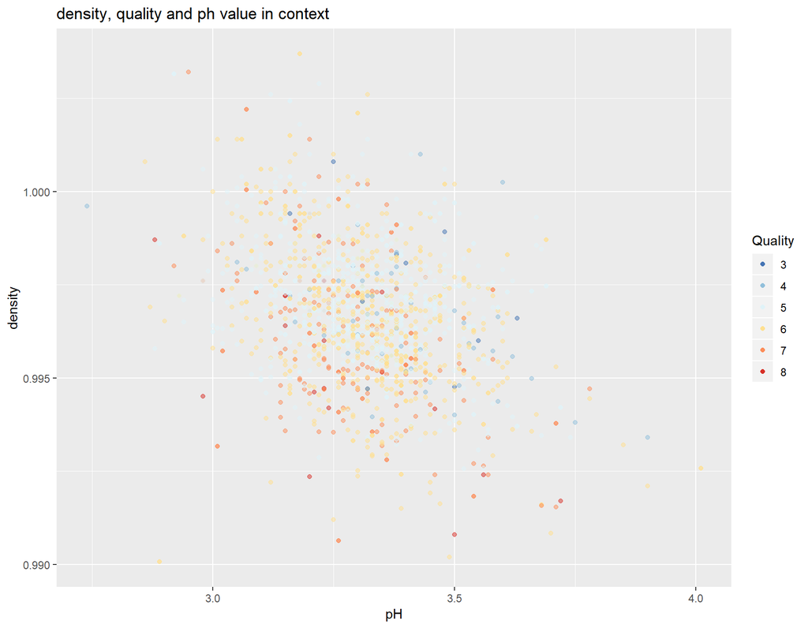

#### citric.acid, residual sugar and chlorides in context

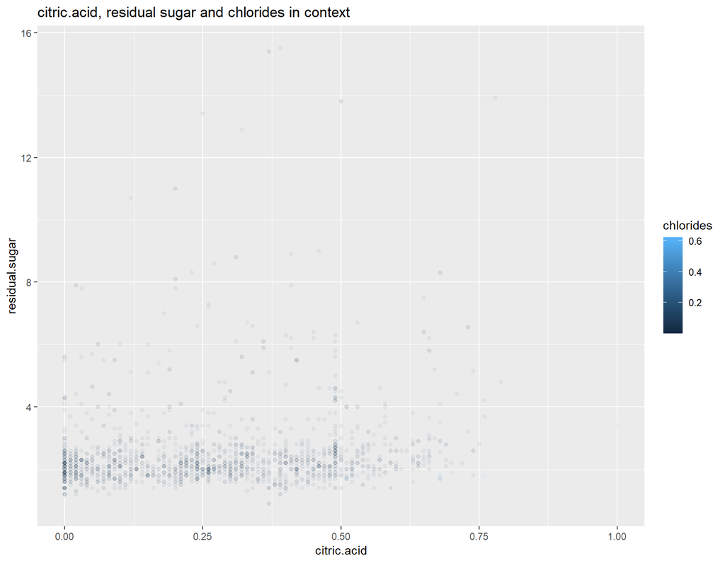

#### citric.acid, residual sugar and quality in context.

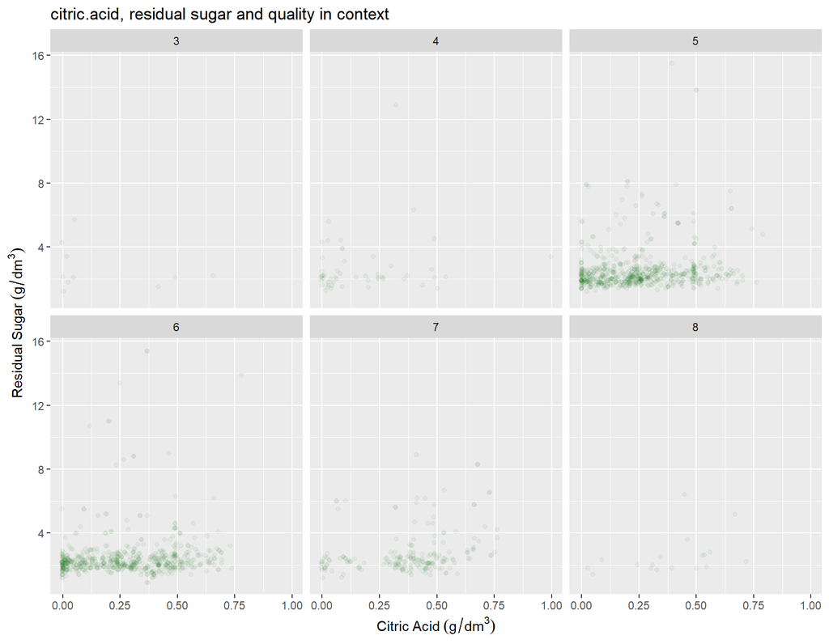

# Multivariate Analysis

# Final Plots and Summary

## first plot

### histogramm of quality

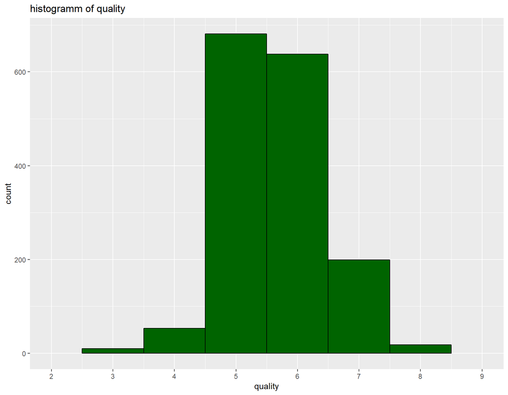

### Description one

the quality range of red wines in our file. the histogram shows a normal distribution. few wines have only a quality range of 3 or 4. most wines with the quality seal of 5 or 6 are in the clear middle field. far fewer wines have a higher quality. the reason might be, that wine is a very everyday good, which is consumed by many people regularly. if wine would be a pure luxury good like e.g. a yacht, then the price and also automatically the quality would be substantially higher. most people will fall back on a red wine, which is affordable and tastes good.

## second plot

### relationship between pH and acidity

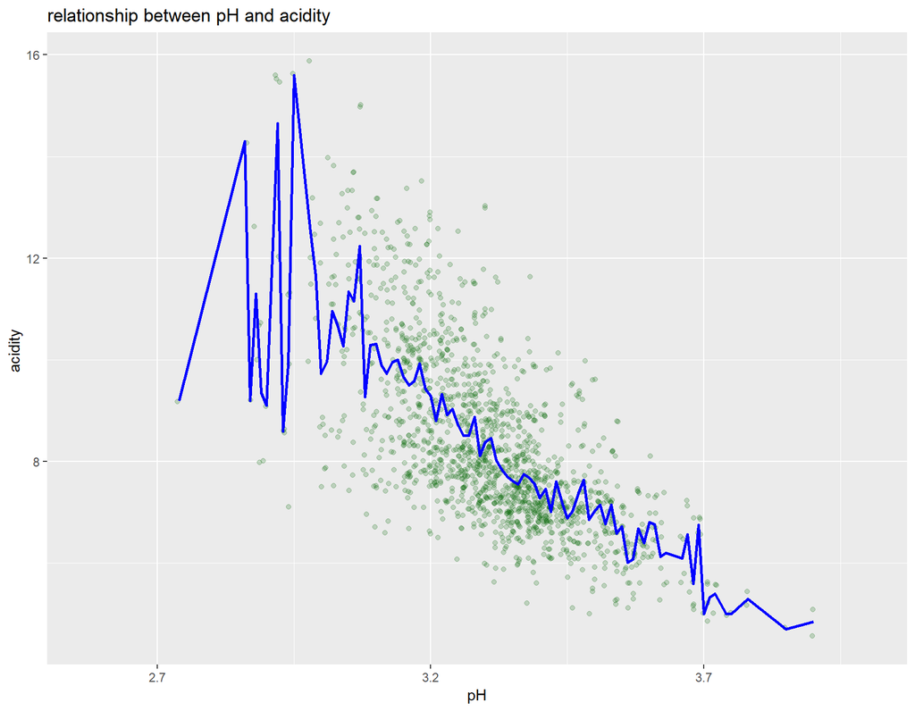

### Description two

the website wineskills gives us the explation why the relationshsip between pH value and acidity is so remarkable. The main acids present in grapes are tartaric and malic. These are ‘organic’ acids, as they contain carbon atoms. They are responsible for the relatively high acidity and low pH (hydrogen ion concentration) of grapes, compared with other fruits, and for the fresh crisp taste of wine. so we can say as higher the lower the pH value as higher the acidity.

## Plot Three

#### citric.acid, residual sugar and quality in context.

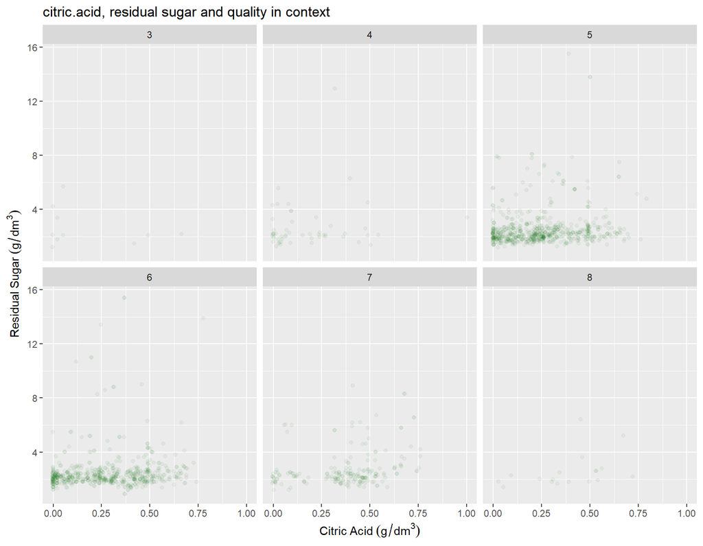

# Reflection

R is not a difficult language to learn, especially if you understand already a few things about statistic, programming and design principles. as we got pyhton lesson already, we are well prepared to learn now R.

i am basically not an alcohol drinker, so it was very hard to understand a file with 1599 different wines. in addition, i have no idea about chemistry and all the chemical terms irritated me a lot. at first i thought that it would be very easy to see a connection between the quality of the wines and their components. but i was completely wrong about that. so i played around with ggpairs to find out which parts of wine depend on each other or whether the data have any conspicuous features. that helped me to familiarize myself with the material. it would be very interesting to find out who has assessed the quality of the wine. were they experts or normal wine customers?

in general it can be said that wine consists of 70-85 % water, 10-15% alcohol and the acid content is about 6-15 g/l.

The sooner the fermentation process is stopped, the more sugar there is in the wine. The wine then tastes all the sweeter. The longer the fermentation process lasts, the less sweetness there is in the wine and the drier the wine tastes. this is the reason why our dataset contains little sugar of higher quality.

further questions which unfortunately cannot be answered with the dataset are the price of wine, who the customers are and in which countries which wine gets the most attention.